# 1. Análisis Exploratorio de Datos Inicial (EDA)

🏢 Olimpiada de Minería de Datos UNAB Caso de estudio: Identificación de patrones en la satisfacción de clientes B2B mediante minería de datos

```r
#Cargamos las librerías
library(tidyverse)
library(visdat)
library(dlookr)
library(flextable)
```

```r
library(inspectdf)
library(qqplotr)
library(ggpmisc)
library(PerformanceAnalytics)
library(corrplot)
library(ggpubr)
library(skimr)
library(janitor)
library(stringr)
```

## 1.1 Carga e importación del dataset

💡 Trabajaremos con encuesta_df, y dejaremos encuesta_raw intacto como respaldo.

```r
#Importamos el csv
encuesta_raw <-read_csv("Encuesta_Satisfaccion_ANONIMIZADA_final.csv", show_col_types = FALSE)
encuesta_df <- encuesta_raw
```

## 1.2 Inspección estructural de la base

### Dimensión del conjunto de datos

```r
dim(encuesta_df)
```

```
## [1] 427  96
```

### Diccionario inicial y tipado de variables

💡 Use skim porque son demasiadas variables para mostrarlas con un str o un summay. Además, los nombres de cada columna son preguntas. Sería bueno limpiar los nombre largos y pasarlos a un tipo “nombre_variable”.

```r
skim(encuesta_df)
```

Data summary

| Name | encuesta_df |
| --- | --- |
| Number of rows | 427 |
| Number of columns | 96 |
| _______________________ |  |
| Column type frequency: |  |
| character | 85 |
| numeric | 11 |
| ________________________ |  |
| Group variables | None |

**Variable type: character**

| skim_variable | n_missing | complete_rate | min | max | empty | n_unique | whitespace |
| --- | --- | --- | --- | --- | --- | --- | --- |
| ID de respuesta | 0 | 1.00 | 7 | 7 | 0 | 322 | 0 |
| Medición | 0 | 1.00 | 10 | 10 | 0 | 3 | 0 |
| Estado de respuesta | 0 | 1.00 | 7 | 9 | 0 | 2 | 0 |
| ¿Cuál es su rol dentro del proyecto? (seleccione el más cercano). | 194 | 0.55 | 12 | 58 | 0 | 63 | 0 |
| ¿Qué tan probable es que recomiende los productos y servicios de ScaffCo a un colega o amigo? | 17 | 0.96 | 1 | 3 | 0 | 8 | 0 |
| ¿Cuál es la principal razón para la nota anterior? | 75 | 0.82 | 1 | 826 | 0 | 343 | 0 |
| Para cada uno de los siguientes aspectos de la atención comercial ¿Cuál diría usted que es su nivel de satisfacción con cada uno de ellos? Siendo 1 muy insatisfecho y 7 muy satisfecho.[Amabilidad en l… | 210 | 0.51 | 1 | 3 | 0 | 8 | 0 |
| Para cada uno de los siguientes aspectos de la atención comercial ¿Cuál diría usted que es su nivel de satisfacción con cada uno de ellos? Siendo 1 muy insatisfecho y 7 muy satisfecho.[Efectividad en … | 210 | 0.51 | 1 | 3 | 0 | 8 | 0 |
| Para cada uno de los siguientes aspectos de la atención comercial ¿Cuál diría usted que es su nivel de satisfacción con cada uno de ellos? Siendo 1 muy insatisfecho y 7 muy satisfecho.[Tiempo de respu… | 210 | 0.51 | 1 | 3 | 0 | 8 | 0 |
| Para cada uno de los siguientes aspectos de la atención comercial ¿Cuál diría usted que es su nivel de satisfacción con cada uno de ellos? Siendo 1 muy insatisfecho y 7 muy satisfecho.[Claridad de la … | 210 | 0.51 | 1 | 3 | 0 | 8 | 0 |
| Para cada uno de los siguientes aspectos de la atención comercial ¿Cuál diría usted que es su nivel de satisfacción con cada uno de ellos? Siendo 1 muy insatisfecho y 7 muy satisfecho.[Claridad de la … | 312 | 0.27 | 1 | 3 | 0 | 7 | 0 |
| Para cada uno de los siguientes aspectos de la atención comercial ¿Cuál diría usted que es su nivel de satisfacción con cada uno de ellos? Siendo 1 muy insatisfecho y 7 muy satisfecho.[Calidad del des… | 312 | 0.27 | 1 | 3 | 0 | 8 | 0 |
| Para cada uno de los siguientes aspectos de la atención comercial ¿Cuál diría usted que es su nivel de satisfacción con cada uno de ellos? Siendo 1 muy insatisfecho y 7 muy satisfecho.[Facilidad para … | 312 | 0.27 | 1 | 3 | 0 | 8 | 0 |
| Para cada uno de los siguientes aspectos de la atención comercial ¿Cuál diría usted que es su nivel de satisfacción con cada uno de ellos? Siendo 1 muy insatisfecho y 7 muy satisfecho.[Servicios de Sc… | 312 | 0.27 | 1 | 3 | 0 | 7 | 0 |
| Para cada uno de los siguientes aspectos de la atención comercial ¿Cuál diría usted que es su nivel de satisfacción con cada uno de ellos? Siendo 1 muy insatisfecho y 7 muy satisfecho.[Productos de Sc… | 312 | 0.27 | 1 | 3 | 0 | 6 | 0 |
| Evalúe los siguientes ítems del Servicio de Asesoría Técnica de ScaffCo, donde 1 es muy insatisfecho y 7 muy satisfecho.[Calidad del servicio de Diseño de Proyectos] | 222 | 0.48 | 1 | 3 | 0 | 7 | 0 |
| Evalúe los siguientes ítems del Servicio de Asesoría Técnica de ScaffCo, donde 1 es muy insatisfecho y 7 muy satisfecho.[Calidad del servicio de Ingeniería] | 222 | 0.48 | 1 | 3 | 0 | 8 | 0 |
| Evalúe los siguientes ítems del Servicio de Asesoría Técnica de ScaffCo, donde 1 es muy insatisfecho y 7 muy satisfecho.[Calidad del servicio de Inducción Técnica] | 222 | 0.48 | 1 | 3 | 0 | 8 | 0 |
| Evalúe los siguientes ítems del Servicio de Asesoría Técnica de ScaffCo, donde 1 es muy insatisfecho y 7 muy satisfecho.[Calidad del servicio de Visita Técnica] | 222 | 0.48 | 1 | 3 | 0 | 6 | 0 |
| Evalúe los siguientes ítems del Servicio de Asesoría Técnica de ScaffCo, donde 1 es muy insatisfecho y 7 muy satisfecho.[Claridad del Informe de la Visita Técnica] | 222 | 0.48 | 1 | 3 | 0 | 8 | 0 |
| Evalúe los siguientes ítems del Servicio de Asesoría Técnica de ScaffCo, donde 1 es muy insatisfecho y 7 muy satisfecho.[Amabilidad del Equipo Técnico] | 222 | 0.48 | 1 | 3 | 0 | 7 | 0 |
| Claridad de la información de los Estados de Pago. | 319 | 0.25 | 1 | 3 | 0 | 7 | 0 |
| ¿Conoce WebScaff? El servicio de Información en línea de su obra de arriendo ScaffCo. | 223 | 0.48 | 2 | 2 | 0 | 2 | 0 |
| ¿Ha usado WebScaff? | 202 | 0.53 | 2 | 2 | 0 | 2 | 0 |
| Evalúe su satisfacción con WebScaff. | 339 | 0.21 | 1 | 3 | 0 | 7 | 0 |
| ¿Conoce CapScaff? El servicio de Inducción virtual interactiva de armado de andamios ScaffCo. | 223 | 0.48 | 2 | 2 | 0 | 2 | 0 |
| ¿Ha usado CapScaff? | 313 | 0.27 | 2 | 2 | 0 | 2 | 0 |
| De los siguientes atributos de ScaffCo, elija los 3 más importantes para Ud. | 58 | 0.86 | 65 | 113 | 0 | 73 | 0 |
| ¿Qué tan fácil fue resolver sus solicitudes o problemas con ScaffCo? | 64 | 0.85 | 1 | 3 | 0 | 8 | 0 |
| Indique 3 palabras con las que identifica a la marca ScaffCo. | 227 | 0.47 | 1 | 143 | 0 | 197 | 0 |

[output cut: 55 more lines]

**Variable type: numeric**

| skim_variable | n_missing | complete_rate | mean | sd | p0 | p25 | p50 | p75 | p100 | hist |
| --- | --- | --- | --- | --- | --- | --- | --- | --- | --- | --- |
| Evalúe su satisfacción con CapScaff. | 391 | 0.08 | 6.44 | 0.81 | 4 | 6.00 | 7 | 7 | 7 | ▁▂▁▃▇ |
| Considerando productos y servicios en general ¿Cuál diría usted que es su nivel de satisfacción con cada uno de ellos? Siendo 1 muy insatisfecho y 7 muy satisfecho.[Servicios de ScaffCo en general] | 328 | 0.23 | 6.37 | 0.96 | 2 | 6.00 | 7 | 7 | 7 | ▁▁▁▅▇ |
| Considerando productos y servicios en general ¿Cuál diría usted que es su nivel de satisfacción con cada uno de ellos? Siendo 1 muy insatisfecho y 7 muy satisfecho.[Productos de ScaffCo en general] | 328 | 0.23 | 6.62 | 0.75 | 3 | 6.00 | 7 | 7 | 7 | ▁▁▁▂▇ |
| Considerando todos los aspectos antes mencionados, ¿Cuál diría usted que es su nivel de satisfacción con los servicios logísticos en general? | 253 | 0.41 | 6.01 | 1.38 | 1 | 6.00 | 6 | 7 | 7 | ▁▁▁▁▇ |
| Considerando todos los aspectos recién mencionados, ¿Cuál diría usted que es su nivel de satisfacción con los servicios de Asesoría Técnica en general? | 258 | 0.40 | 6.20 | 1.33 | 1 | 6.00 | 7 | 7 | 7 | ▁▁▁▁▇ |
| Evalúe su satisfacción con WebScaff | 357 | 0.16 | 5.93 | 1.58 | 1 | 5.25 | 7 | 7 | 7 | ▁▁▁▁▇ |
| Evalúe su satisfacción con CapScaff | 400 | 0.06 | 6.22 | 1.31 | 2 | 6.00 | 7 | 7 | 7 | ▁▁▁▃▇ |
| Evalúe su satisfacción con ScanScaff | 416 | 0.03 | 7.00 | 0.00 | 7 | 7.00 | 7 | 7 | 7 | ▁▁▇▁▁ |
| Evalúe su satisfacción con XR App | 420 | 0.02 | 6.71 | 0.49 | 6 | 6.50 | 7 | 7 | 7 | ▃▁▁▁▇ |
| Considerando productos y servicios en general ¿Cuál diría usted que es su nivel de satisfacción con cada uno de ellos? Siendo 1 muy insatisfecho y 7 muy satisfecho[Servicios de ScaffCo en general] | 264 | 0.38 | 6.07 | 1.39 | 1 | 6.00 | 6 | 7 | 7 | ▁▁▁▁▇ |
| Considerando productos y servicios en general ¿Cuál diría usted que es su nivel de satisfacción con cada uno de ellos? Siendo 1 muy insatisfecho y 7 muy satisfecho[Productos de ScaffCo en general] | 264 | 0.38 | 6.32 | 1.22 | 1 | 6.00 | 7 | 7 | 7 | ▁▁▁▁▇ |

# 2. Preprocesamiento, Limpieza y Estandarización de Datos

## 2.1 Estandarización

### Homologación semántica entre olas y creación del diccionario de variables

El propósito es mapear preguntas que variaron en su redacción entre olas a un identificador único estándar. (no considera preguntas con corchetes)

```r
equivalencias <- tribble(
  ~nombre_original, ~concepto,
  "ID de respuesta", "id_respuesta",
  "Medición", "medicion",
  "Estado de respuesta", "estado_respuesta",
  "Periodo", "periodo",

  #Variables Demográficas / Contexto

  "¿Cuál es su rol dentro del proyecto? (seleccione el más cercano).", "rol_proyecto",
  "¿Cuál es su rol dentro del proyecto? (Seleccione el que más se aproxime)", "rol_proyecto",
  "¿En cuál de estos sectores presta servicios tu empresa?(Puedes seleccionar más de una opción si corresponde)", "sector_empresa",
  "¿En cuál de estos sectores presta servicios su empresa?(Puede seleccionar más de una opción si corresponde)", "sector_empresa",
  "¿En qué región del país se encontraba el proyecto para el cual su empresa contrató productos o servicios de ScaffCo?(Si ha trabajado en más de una región, por favor indique la principal)", "region_proyecto",
  "Seleccione cuando fue su última interacción con el equipo ScaffCo (Entiéndase por interacción cualquier tipo de comunicación ya sea escrita, telefónica o presencial, o cotización, servicios prestados, o cualquier otro tipo de contacto con la empresa)", "ultima_interaccion",

  # Métricas Globales de Percepción / Satisfacción

  "¿Qué tan probable es que recomiende los productos y servicios de ScaffCo a un colega o amigo?", "recomendacion",
  "¿Cuál es la principal razón para la nota anterior?", "razon_recomendacion",
  "¿Qué tan fácil fue resolver sus solicitudes o problemas con ScaffCo?", "facilidad_resolucion",
  "Considerando el precio, servicio y productos que recibe de ScaffCo ¿Qué nota le pondría usted a ScaffCo en cuanto a esta relación precio-calidad?", "precio_calidad",
  "Considerando todos los aspectos antes mencionados, ¿Cuál diría usted que es su nivel de satisfacción con los servicios logísticos en general?", "satisfaccion_logistica_general",
  "Considerando todos los aspectos recién mencionados, ¿Cuál diría usted que es su nivel de satisfacción con los servicios de Asesoría Técnica en general?", "satisfaccion_asesoria_tecnica_general",

  # Servicios Comerciales y Facturación

  "Claridad de la información de los Estados de Pago.", "claridad_estados_pago",
  "Evalúe la claridad de la información de los Estados de Pago.", "claridad_estados_pago",

  # Plataforma WebScaff

  "¿Conoce WebScaff? El servicio de Información en línea de su obra de arriendo ScaffCo.", "conoce_webscaff",
  "¿Conoce WebScaff? (El servicio de información en línea de su obra de arriendo ScaffCo)", "conoce_webscaff",
  "¿Ha usado WebScaff?", "uso_webscaff",
  "Evalúe su satisfacción con WebScaff.", "satisfaccion_webscaff",
  "Evalúe su satisfacción con WebScaff", "satisfaccion_webscaff",
  "¿Nos puede comentar por qué no ha usado WebScaff?(Marque todas las que correspondan)", "motivo_no_uso_webscaff",
  "¿Qué le gustaría agregar o mejorar en WebScaff?", "mejora_webscaff",

  # Plataforma CapScaff

  "¿Conoce CapScaff? El servicio de Inducción virtual interactiva de armado de andamios ScaffCo.", "conoce_capscaff",
  "¿Conoce CapScaff? (El servicio de Inducción virtual interactiva de armado de andamios ScaffCo)", "conoce_capscaff",
  "¿Ha usado CapScaff?", "uso_capscaff",
  "Evalúe su satisfacción con CapScaff.", "satisfaccion_capscaff",
  "Evalúe su satisfacción con CapScaff", "satisfaccion_capscaff",
  "¿Nos puede comentar por qué no ha usado CapScaff?(Marque todas las que correspondan)", "motivo_no_uso_capscaff",

  # Plataforma ScanScaff

  "¿Conoce ScanScaff? (El servicio de ScaffCo para realizar levantamientos digitales de estructuras mediante nube de puntos)", "conoce_scanscaff",
  "¿Ha usado ScanScaff?", "uso_scanscaff",
  "¿Nos puede comentar por qué no ha usado ScanScaff?", "motivo_no_uso_scanscaff",
  "Evalúe su satisfacción con ScanScaff", "satisfaccion_scanscaff",

  # Plataforma XR App

  "¿Conoce XR App? (La aplicación de construcción digital de ScaffCo, basada en realidad aumentada)", "conoce_xr_app",
  "¿Ha usado XR App?", "uso_xr_app",
  "Evalúe su satisfacción con XR App", "satisfaccion_xr_app",
  "¿Nos puede comentar por qué no ha usado XR App?(Marque todas las que correspondan)", "motivo_no_uso_xr_app",

  # Atributos de Marca y Cierre

  "De los siguientes atributos de ScaffCo, elija los 3 más importantes para Ud.", "atributos_importantes",
  "Indique 3 palabras con las que identifica a la marca ScaffCo.", "palabras_marca",
  "Indique 3 palabras con las que identifica a la marca ScaffCo", "palabras_marca",
  "¿Tiene algún comentario o sugerencia para nosotros? Indique cualquier punto que pudiera no estar cubierto en esta encuesta, recuerde que los mismos son anónimos.", "comentario_sugerencia",
  "¿Tiene algún comentario o sugerencia para nosotros? Indique cualquier punto que pudiera no estar cubierto en esta encuesta, recuerde que los mismos son anónimos", "comentario_sugerencia",
  "¿Le gustaría recibir el newsletter de ScaffCo?", "newsletter",
  "¿Quiere ser contactado para profundizar en sus respuestas?", "quiere_contacto"
)
```

### Extracción y limpieza automática de atributos con corchetes

Se construye un diccionario automatizado para homologar preguntas manuales y limpiar atributos matriciales con corchetes a formato snake_case único.

```r
diccionario_nombres <- tibble(nombre_original = names(encuesta_df)) %>%
  mutate(
    #Detectar preguntas tipo matriz con ítems entre conchetes
    tiene_corchete = str_detect(nombre_original, "\\[.+\\]"),
    atributo_extraido = str_extract(nombre_original, "(?<=\\[).+(?=\\])")
  ) %>%
  left_join(equivalencias, by = "nombre_original")
```

```r
#  Limpiamos los atributos de corchete uno por uno
diccionario_nombres <- diccionario_nombres %>%
  mutate(
    #Para ítems con corchetes, estandarizamos el texto a snake_case
    concepto_bracket = if_else(
      tiene_corchete,
      map_chr(atributo_extraido, make_clean_names),
      NA_character_
    ),
    concepto_final = coalesce(concepto, concepto_bracket)
  )
```

```r
# Generar el nombre final único por columna
diccionario_nombres <- diccionario_nombres %>%
  mutate(
    nombre_limpio = make.unique(concepto_final, sep = "_v")
  )

# Verificación: debe dar 0 y 0
diccionario_nombres %>% summarise(
  nas = sum(is.na(nombre_limpio)),
  duplicados = sum(duplicated(nombre_limpio))
)
```

```
## # A tibble: 1 × 2
##     nas duplicados
##   <int>      <int>
## 1     0          0
```

```r
# Aplicar al dataset y renombrado del dataset original.
names(encuesta_df) <- diccionario_nombres$nombre_limpio
names(encuesta_df)
```

```
##  [1] "id_respuesta"
##  [2] "medicion"
##  [3] "estado_respuesta"
##  [4] "rol_proyecto"
##  [5] "recomendacion"
##  [6] "razon_recomendacion"
##  [7] "amabilidad_en_la_atencion_comercial"
##  [8] "efectividad_en_la_atencion_comercial"
##  [9] "tiempo_de_respuesta_en_las_cotizaciones_solicitadas"
## [10] "claridad_de_la_informacion_en_cotizaciones"
## [11] "claridad_de_la_informacion_en_planos"
## [12] "calidad_del_despacho_de_los_equipos_ausencia_de_errores_de_envio_estado_del_material"
## [13] "facilidad_para_coordinar_y_realizar_devolucion_de_equipos_en_arriendo"
## [14] "servicios_de_scaff_co_en_general"
## [15] "productos_de_scaff_co_en_general"
```

[output cut: 81 more lines]

```r
# Guardar el diccionario para sección 4.2
write_csv(diccionario_nombres, "diccionario_variables.csv")
```

```r
#Completitud de datos. Calculamos la proporción de datos faltantes por columna
missing_por_variable <- encuesta_df %>%
  summarise(across(everything(), ~ round(mean(is.na(.)) * 100, 1))) %>%
  pivot_longer(everything(), names_to = "nombre_limpio", values_to = "pct_missing")

diccionario_nombres <- diccionario_nombres %>%
  left_join(missing_por_variable, by = "nombre_limpio")

write_csv(diccionario_nombres, "diccionario_variables.csv")
```

## 2.2 Tipificación de escalas tipo Likert y auditoría de faltantes

*ESTO SE MODIFICO PARA OBTENER LAS 19 VARIABLES NUMERICAS*

💡 Entrega las variables de tipo escala.

```r
# Detectar TODAS las columnas de escala 1-7
es_escala_1_a_7 <- function(x) {
  if (is.numeric(x)) {
    valores <- unique(na.omit(x))
    return(length(valores) > 0 && all(valores %in% 1:7))
  }
  if (!is.character(x)) return(FALSE)
  valores <- unique(na.omit(x))
  length(valores) > 0 && all(valores %in% c("1","2","3","4","5","6","7","N/A"))
}

#Vector con los nombres limpios de todas las escalas de evaluación
columnas_escala <- names(encuesta_df)[sapply(encuesta_df, es_escala_1_a_7)]
length(columnas_escala)
```

```
## [1] 63
```

*ESTO SE CAMBIO PARA REVISAR EL TIPO DE CADA COLUMNA ANTES DE DECIDIR QUE HACER*

```r
# Tratar N/A como valor faltante real de R y asegurar conversión numérica segura
encuesta_df <- encuesta_df %>%
  mutate(across(
    all_of(columnas_escala),
    ~ as.numeric(na_if(as.character(.x), "N/A"))
  ))
```

```r
resumen_final <- as_tibble(skim(encuesta_df))
resumen_final %>% count(skim_type)
```

```
## # A tibble: 2 × 2
##   skim_type     n
##   <chr>     <int>
## 1 character    33
## 2 numeric      63
```

⬇️ Verificamos que no existan valores fuera de la escala 1 a 7

```r
#Evaluar los rangos, entre 1 y 7 estan OK
encuesta_df %>%
  select(all_of(columnas_escala)) %>%
  reframe(across(everything(), ~ range(.x, na.rm = TRUE))) %>%
  unlist() %>%
  unique()
```

```
## [1] 1 7 2 4 3 6
```

```r
#Evaluar que columnas tienen minimo 2 o 3
encuesta_df %>%
  select(all_of(columnas_escala)) %>%
  summarise(across(everything(), ~ min(.x, na.rm = TRUE))) %>%
  pivot_longer(everything(), names_to = "variable", values_to = "minimo") %>%
  filter(minimo > 1)
```

```
## # A tibble: 14 × 2
##    variable                                                               minimo
##    <chr>                                                                   <dbl>
##  1 satisfaccion_webscaff                                                       2
##  2 satisfaccion_capscaff                                                       4
##  3 claridad_en_la_informacion_de_planos_e_informes_entregados                  2
##  4 evaluacion_general_de_los_procesos_operacionales                            3
##  5 seguridad_de_sus_andamios                                                   2
##  6 coincidencia_entre_el_producto_solicitado_y_el_producto_recibido_v1         3
##  7 efectividad_del_control_de_calidad_aplicado_antes_del_despacho_del_ma…      3
##  8 calidad_del_despacho_de_los_equipos_ausencia_de_errores_de_envio_esta…      3
##  9 facilidad_para_coordinar_y_realizar_devolucion_de_equipos_en_arriendo…      3
## 10 servicios_de_scaff_co_en_general_v1                                         2
## 11 productos_de_scaff_co_en_general_v1                                         3
## 12 satisfaccion_capscaff_v1                                                    2
## 13 satisfaccion_scanscaff                                                      7
## 14 satisfaccion_xr_app                                                         6
```

```r
#Diagnóstico General
diagnose(encuesta_df) %>%
  flextable() %>%
  autofit()
```

| variables | types | missing_count | missing_percent | unique_count | unique_rate |
| --- | --- | --- | --- | --- | --- |
| id_respuesta | character | 0 | 0.000000 | 322 | 0.754098361 |
| medicion | character | 0 | 0.000000 | 3 | 0.007025761 |
| estado_respuesta | character | 0 | 0.000000 | 2 | 0.004683841 |
| rol_proyecto | character | 194 | 45.433255 | 64 | 0.149882904 |
| recomendacion | numeric | 18 | 4.215457 | 8 | 0.018735363 |
| razon_recomendacion | character | 75 | 17.564403 | 344 | 0.805620609 |
| amabilidad_en_la_atencion_comercial | numeric | 218 | 51.053864 | 8 | 0.018735363 |
| efectividad_en_la_atencion_comercial | numeric | 222 | 51.990632 | 8 | 0.018735363 |
| tiempo_de_respuesta_en_las_cotizaciones_solicitadas | numeric | 224 | 52.459016 | 8 | 0.018735363 |
| claridad_de_la_informacion_en_cotizaciones | numeric | 224 | 52.459016 | 8 | 0.018735363 |
| claridad_de_la_informacion_en_planos | numeric | 324 | 75.878220 | 7 | 0.016393443 |
| calidad_del_despacho_de_los_equipos_ausencia_de_errores_de_envio_estado_del_material | numeric | 324 | 75.878220 | 8 | 0.018735363 |
| facilidad_para_coordinar_y_realizar_devolucion_de_equipos_en_arriendo | numeric | 329 | 77.049180 | 8 | 0.018735363 |
| servicios_de_scaff_co_en_general | numeric | 314 | 73.536300 | 7 | 0.016393443 |
| productos_de_scaff_co_en_general | numeric | 317 | 74.238876 | 6 | 0.014051522 |
| calidad_del_servicio_de_diseno_de_proyectos | numeric | 249 | 58.313817 | 7 | 0.016393443 |
| calidad_del_servicio_de_ingenieria | numeric | 249 | 58.313817 | 8 | 0.018735363 |
| calidad_del_servicio_de_induccion_tecnica | numeric | 244 | 57.142857 | 8 | 0.018735363 |
| calidad_del_servicio_de_visita_tecnica | numeric | 252 | 59.016393 | 6 | 0.014051522 |
| claridad_del_informe_de_la_visita_tecnica | numeric | 253 | 59.250585 | 8 | 0.018735363 |
| amabilidad_del_equipo_tecnico | numeric | 241 | 56.440281 | 7 | 0.016393443 |
| claridad_estados_pago | numeric | 347 | 81.264637 | 7 | 0.016393443 |
| conoce_webscaff | character | 223 | 52.224824 | 3 | 0.007025761 |
| uso_webscaff | character | 202 | 47.306792 | 3 | 0.007025761 |
| satisfaccion_webscaff | numeric | 340 | 79.625293 | 7 | 0.016393443 |
| conoce_capscaff | character | 223 | 52.224824 | 3 | 0.007025761 |
| uso_capscaff | character | 313 | 73.302108 | 3 | 0.007025761 |
| satisfaccion_capscaff | numeric | 391 | 91.569087 | 5 | 0.011709602 |
| atributos_importantes | character | 58 | 13.583138 | 74 | 0.173302108 |
| facilidad_resolucion | numeric | 79 | 18.501171 | 8 | 0.018735363 |

[output cut: 66 more lines]

## 2.3 Auditoría de identificadores de respuesta duplicados

Detección de duplicados

```r
# Evaluar si las filas con el mismo id_respuesta son la misma persona respondiendo dos veces o son personas distinas a las que se les asigno el mismo id por error
ids_duplicados <- encuesta_df %>%
  count(id_respuesta, medicion) %>%
  filter(n > 1) %>%
  pull(id_respuesta)

#Visualización
encuesta_df %>%
  filter(id_respuesta %in% ids_duplicados[1:3]) %>%
  select(id_respuesta, medicion, estado_respuesta, periodo, recomendacion) %>%
  arrange(id_respuesta)
```

```
## # A tibble: 6 × 5
##   id_respuesta medicion   estado_respuesta periodo recomendacion
##   <chr>        <chr>      <chr>            <chr>           <dbl>
## 1 M2-0001      Medición 2 COMPLETED        2025-07             7
## 2 M2-0001      Medición 2 COMPLETED        2025-07             7
## 3 M2-0002      Medición 2 COMPLETED        2025-07             7
## 4 M2-0002      Medición 2 COMPLETED        2025-07             7
## 5 M2-0003      Medición 2 COMPLETED        2025-07             7
## 6 M2-0003      Medición 2 COMPLETED        2025-07             7
```

```r
#Visualización resumida
resumen <- encuesta_df %>%
  filter(id_respuesta %in% ids_duplicados[]) %>%
  filter(medicion == "Medición 2") %>%
  group_by(medicion, estado_respuesta) %>%
  summarise(cantidad = n(), .groups = "drop")

print(resumen)
```

```
## # A tibble: 2 × 3
##   medicion   estado_respuesta cantidad
##   <chr>      <chr>               <int>
## 1 Medición 2 COMPLETED              68
## 2 Medición 2 PARTIAL                 6
```

```r
#Visualización resumida. Agregamos recomendación para visualizar la cantidad según puntaje.
resumen <- encuesta_df %>%
  filter(id_respuesta %in% ids_duplicados[]) %>%
  filter(medicion == "Medición 2") %>%
  group_by(medicion, estado_respuesta, recomendacion) %>%
  summarise(cantidad = n(), .groups = "drop")

print(resumen)
```

```
## # A tibble: 8 × 4
##   medicion   estado_respuesta recomendacion cantidad
##   <chr>      <chr>                    <dbl>    <int>
## 1 Medición 2 COMPLETED                    4        2
## 2 Medición 2 COMPLETED                    5        2
## 3 Medición 2 COMPLETED                    6        8
## 4 Medición 2 COMPLETED                    7       56
## 5 Medición 2 PARTIAL                      5        1
## 6 Medición 2 PARTIAL                      6        2
## 7 Medición 2 PARTIAL                      7        2
## 8 Medición 2 PARTIAL                     NA        1
```

```r
#Evaluar si son filas exactamente duplicadas
duplicados_exactos <- encuesta_df %>%
  filter(id_respuesta %in% ids_duplicados) %>%
  group_by(id_respuesta) %>%
  mutate(fila_identica_a_otra = duplicated(across(everything())) | duplicated(across(everything()), fromLast = TRUE)) %>%
  ungroup()

# ¿Cuántas de las filas duplicadas por id son también 100% idénticas en TODAS las columnas?
duplicados_exactos %>%
  count(fila_identica_a_otra)
```

```
## # A tibble: 1 × 2
##   fila_identica_a_otra     n
##   <lgl>                <int>
## 1 FALSE                  189
```

👀 Como sólo encontramos valores `FALSE` podemos decir que, aunque el `id_respuesta` este repetido, sus datos internos cambian entre una fila y otra. Esto quiere decir que se les asignó el mismo ID por error.

```r
#Decisión de limpieza
encuesta_df <- encuesta_df %>%
  mutate(id_fila = row_number(), .before = id_respuesta)

# Verificación: ahora sí debe ser 100% único
n_distinct(encuesta_df$id_fila) == nrow(encuesta_df)
```

```
## [1] TRUE
```

👀⬆️ Con `True` confirmamos que cada fila de dataset es única respecto a su posisición. Por ello, se genera una clave artificial única para manterner la trazabilidad de cada fila.

## 2.4 Evaluación y tratamiento de respuestas parciales

Estado de respuestas: COMPLETED — PARTIAL

```r
# Revisar la distribución de registros por Medición y Estado de Respuesta
distribucion_medicion_estado <- encuesta_df %>%
  count(medicion, estado_respuesta)

print(distribucion_medicion_estado)
```

```
## # A tibble: 6 × 3
##   medicion   estado_respuesta     n
##   <chr>      <chr>            <int>
## 1 Medición 1 COMPLETED          105
## 2 Medición 1 PARTIAL             24
## 3 Medición 2 COMPLETED           95
## 4 Medición 2 PARTIAL              9
## 5 Medición 3 COMPLETED          154
## 6 Medición 3 PARTIAL             40
```

```r
#Respuestas parciales de la encuesta
encuesta_df %>%
  filter(estado_respuesta == "PARTIAL") %>%
  summarise(across(everything(), ~mean(!is.na(.x)))) %>%
  pivot_longer(everything(), names_to = "variable", values_to = "pct_completo") %>%
  summarise(pct_completo_promedio = mean(pct_completo))
```

```
## # A tibble: 1 × 1
##   pct_completo_promedio
##                   <dbl>
## 1                 0.200
```

⬆️ 👀 Obs 1: Esto da, en promedio, qué porcentaje de todas las columnas alcanzó a responder una fila PARTIAL típica. Con ese número decidimos con criterio: si completan poquísimo (ej. <15%), lo más sano es excluirlas del análisis cuantitativo (aunque se puede mantener el n=427 mencionado, aclarando cuántas quedan útiles). Si completan una porción razonable, se pueden mantener y dejar que cada análisis use listwise/pairwise deletion según corresponda.

```r
#Considerando como variable objetivo RECOMENDACION, revisar si en filas PARTIAL contestaron esto y abandonaron el resto
encuesta_df %>%
  filter(estado_respuesta == "PARTIAL") %>%
  summarise(
    n_partial = n(),
    con_recomendacion = sum(!is.na(recomendacion)),
    pct_con_recomendacion = mean(!is.na(recomendacion))
  )
```

```
## # A tibble: 1 × 3
##   n_partial con_recomendacion pct_con_recomendacion
##       <int>             <int>                 <dbl>
## 1        73                56                 0.767
```

⬆️Entonces, un 76% de registros parciales alcanzaron a rellenar la recomendación antes de abandonar la encuesta. Esto responde a la pregunta: *¿Los usuarios abandonan la encuesta antes de llegar al final, o alcanzan a responder las preguntas clave (como la recomendación)?*

```r
print(diccionario_nombres, n = Inf, width = Inf)
```

```
## # A tibble: 96 × 8
##    nombre_original
##    <chr>
##  1 ID de respuesta
##  2 Medición
##  3 Estado de respuesta
##  4 ¿Cuál es su rol dentro del proyecto? (seleccione el más cercano).
##  5 ¿Qué tan probable es que recomiende los productos y servicios de ScaffCo a u…
##  6 ¿Cuál es la principal razón para la nota anterior?
##  7 Para cada uno de los siguientes aspectos de la atención comercial ¿Cuál dirí…
##  8 Para cada uno de los siguientes aspectos de la atención comercial ¿Cuál dirí…
##  9 Para cada uno de los siguientes aspectos de la atención comercial ¿Cuál dirí…
## 10 Para cada uno de los siguientes aspectos de la atención comercial ¿Cuál dirí…
## 11 Para cada uno de los siguientes aspectos de la atención comercial ¿Cuál dirí…
## 12 Para cada uno de los siguientes aspectos de la atención comercial ¿Cuál dirí…
```

[output cut: 770 more lines]

## 2.5 Detección de colisiones de conceptos en la estandarización

Evaluacion conceptos múltiples

Cuenta cuantas veces aparece cada concepto_final en el diccionario y se queda con los que aparecen más de una vez (los homologados). Sirve para saber cuales de las 96 columnas originales corresponden a preguntas repetidas que hay que fusionar.

```r
#Control de calidad sobre la estandarización de variables.

conceptos_multiples <- diccionario_nombres %>%
  count(concepto_final) %>%
  filter(n > 1) %>%
  pull(concepto_final)

length(conceptos_multiples)
```

```
## [1] 26
```

### Validación automatizada de consistencia entre variantes

Bucle de validación

Por cada concepto homologado, revisa si todas sus variantes (_v1,_v2) tienen el mismo tipo de dato (character-numeric). Si no tienen el mismo tipo da una advertencia. Sirve para verificar que todas las variantes de un mismo concepto tengan el mismo tipo de dato antes de fusionar.

```r
#Bucle de validación cruzada de tipos de datos
for (concepto_actual in conceptos_multiples) {
  columnas_variante <- diccionario_nombres %>%
    filter(concepto_final == concepto_actual) %>%
    pull(nombre_limpio)

  tipos <- sapply(encuesta_df[columnas_variante], class)

  if (length(unique(tipos)) > 1) {
    cat("⚠️ CONFLICTO en concepto:", concepto_actual, "\n")
    print(columnas_variante)
    print(tipos)
    cat("\n")
  }
}
```

## 2.6 Consolidación e integración de la base de trabajo

Fusiona las variantes de cada concepto en una sola columna y verifica que la fusión no dejó vacíos.

⬆️

```r
for (concepto_actual in conceptos_multiples) {
  columnas_variante <- diccionario_nombres %>%
    filter(concepto_final == concepto_actual) %>%
    pull(nombre_limpio)

  encuesta_df[[concepto_actual]] <- do.call(coalesce, encuesta_df[columnas_variante])
}

# Verificación: rol_proyecto debería quedar con 0% de missing
encuesta_df %>% summarise(missing_rol = mean(is.na(rol_proyecto)))
```

```
## # A tibble: 1 × 1
##   missing_rol
##         <dbl>
## 1           0
```

## 2.7 Recodificación y tratamiento de la categoría “Otros” en el rol del proyecto

```r
encuesta_df <- encuesta_df %>%
  mutate(rol_proyecto = case_when(
    !str_starts(rol_proyecto, "Otros \\(especifique\\)") ~ rol_proyecto,
    str_detect(rol_proyecto, regex("compra|adquisic|comex|subcontrato", ignore_case = TRUE)) ~ "Compras / Abastecimiento",
    str_detect(rol_proyecto, regex("prevenci|hse", ignore_case = TRUE)) ~ "Prevención de Riesgos / HSE",
    str_detect(rol_proyecto, regex("superintendente", ignore_case = TRUE)) ~ "Superintendencia",
    str_detect(rol_proyecto, regex("capataz|maestro|^otros \\(especifique\\) - m1", ignore_case = TRUE)) ~ "Capataz / Maestro de Obra",
    str_detect(rol_proyecto, regex("administrat|rrll|recursos humanos|finanzas", ignore_case = TRUE)) ~ "Administración / Finanzas",
    str_detect(rol_proyecto, regex("ingenier|estudio|bim|constructibilidad|formulador", ignore_case = TRUE)) ~ "Ingeniería / Estudios",
    str_detect(rol_proyecto, regex("operac|log.stica|supervisor|mantenci", ignore_case = TRUE)) ~ "Operaciones / Logística",
    str_detect(rol_proyecto, regex("comercial", ignore_case = TRUE)) ~ "Comercial",
    str_detect(rol_proyecto, regex("calidad", ignore_case = TRUE)) ~ "Calidad",
    str_detect(rol_proyecto, regex("gerente general|director|socio|coordinador general", ignore_case = TRUE)) ~ "Dirección General",
    TRUE ~ "Otros"
  ))

# Verificación: cuántos quedaron sin clasificar
  encuesta_df %>%
  count(rol_proyecto) %>%
  arrange(rol_proyecto == "Otros", desc(n))
```

```
## # A tibble: 20 × 2
##    rol_proyecto                        n
##    <chr>                           <int>
##  1 Administrador de Obra              75
##  2 Gerente de Proyecto                53
##  3 Jefe de Bodega                     49
##  4 Jefe de Terreno                    44
##  5 Oficina Técnica                    37
##  6 Prevencionista de Riesgos          30
##  7 Supervisor de Andamios             25
##  8 Administración / Finanzas          18
##  9 Compras / Abastecimiento           12
## 10 Ingeniería / Estudios              11
## 11 Capataz / Maestro de Obra           8
## 12 Operaciones / Logística             8
## 13 Dirección General                   7
## 14 Jefe de otras áreas no listadas     7
## 15 Jefe de Obra                        5
## 16 Prevención de Riesgos / HSE         3
## 17 Comercial                           2
## 18 Superintendencia                    2
## 19 Calidad                             1
## 20 Otros                              30
```

## 2.8 Tratamiento de ítems de selección múltiple

Separa preguntas de selección múltiple (una fila por opción elegida) para poder contarlas.

```r
encuesta_df_sector_largo <- encuesta_df %>%
  filter(!is.na(sector_empresa)) %>%
  separate_rows(sector_empresa, sep = ",")

encuesta_df_atributos_largo <- encuesta_df %>%
  filter(!is.na(atributos_importantes)) %>%
  separate_rows(atributos_importantes, sep = ",")  %>%
  mutate(atributos_importantes = trimws(atributos_importantes))

encuesta_df_atributos_largo %>% count(atributos_importantes, sort = TRUE)
```

```
## # A tibble: 9 × 2
##   atributos_importantes                         n
##   <chr>                                     <int>
## 1 Seguridad de los Andamios                   208
## 2 Calidad del Producto                        192
## 3 Servicio técnico (Visitas e Inducciones)    144
## 4 Certificación de Calidad                    130
## 5 Capacidad Técnica para Desafíos Complejos   111
## 6 Marca Reconocida en el Mercado              107
## 7 Cobertura y Stock Disponible                102
## 8 Servicio de Ingeniería                       79
## 9 Fabricación Alemana                          34
```

## 2.9 Consolidación del subconjunto numérico homologado

```r
#De los conceptos homologados, filtra solo los de tipo escala 1-7
diccionario_nombres_escala <- diccionario_nombres %>%
  filter(concepto_final %in% conceptos_multiples,
         nombre_limpio %in% columnas_escala)

length(unique(diccionario_nombres_escala$concepto_final))
```

```
## [1] 20
```

Roles disponibles

```r
encuesta_df %>%
  count(rol_proyecto)
```

```
## # A tibble: 20 × 2
##    rol_proyecto                        n
##    <chr>                           <int>
##  1 Administración / Finanzas          18
##  2 Administrador de Obra              75
##  3 Calidad                             1
##  4 Capataz / Maestro de Obra           8
##  5 Comercial                           2
##  6 Compras / Abastecimiento           12
##  7 Dirección General                   7
##  8 Gerente de Proyecto                53
##  9 Ingeniería / Estudios              11
## 10 Jefe de Bodega                     49
## 11 Jefe de Obra                        5
## 12 Jefe de Terreno                    44
## 13 Jefe de otras áreas no listadas     7
## 14 Oficina Técnica                    37
## 15 Operaciones / Logística             8
## 16 Otros                              30
## 17 Prevencionista de Riesgos          30
## 18 Prevención de Riesgos / HSE         3
## 19 Superintendencia                    2
## 20 Supervisor de Andamios             25
```

### Verificación y trazabilidad del conjunto de 19 variables comunes

¿Qué se hizo para obtener las 19 variables?

1. De los 26 conceptos homologados (`conceptos_multiples`), se identificaron 20 que corresponden a variables de escala 1-7. Los otros 6 son homologaciones de variables de texto o categóricas (rol_proyecto, sector_empresa,comentario_sugerencia, palabras_marca, conoce_webscaff, conoce_capscaff) y no aplican aquí.
2. De esas 20 numéricas homologadas, se revisó en cuáles de las tres mediciones cada variante tiene datos reales (no solo missing por diseño del instrumento). Solo 16 están presentes en las tres olas; las otras 4 (claridad_estados_pago, claridad_en_la_informacion_de_planos_e_informes_entregados, coincidencia_entre_el_producto_solicitado_y_el_producto_recibido, disponibilidad_de_productos_y_accesorios) solo se preguntaron en 2 de las 3 mediciones.

Sumando esas 16 a las 3 variables numéricas que ya eran literalmente comunes a las tres olas sin necesitar homologación (recomendacion, facilidad_resolucion, precio_calidad), se llega a las 19 variables numéricas comparables entre olas que indica la guía.

```r
cobertura_por_variante <- diccionario_nombres_escala %>%
  distinct(nombre_limpio, concepto_final) %>%
  mutate(
    mediciones_activas = map(nombre_limpio, function(nombre_col) {
      valores_no_na <- !is.na(encuesta_df[[nombre_col]])
      unique(encuesta_df$medicion[valores_no_na])
    })
  )

cobertura_por_concepto <- cobertura_por_variante %>%
  group_by(concepto_final) %>%
  summarise(n_mediciones_totales = length(unique(unlist(mediciones_activas))))

numericas_3_olas <- cobertura_por_concepto %>%
  filter(n_mediciones_totales == 3) %>%
  pull(concepto_final)

length(numericas_3_olas)        # 16
```

```
## [1] 16
```

```r
length(numericas_3_olas) + 3    # + recomendacion, facilidad_resolucion, precio_calidad = 19
```

```
## [1] 19
```

### Variables numericas

```r
# Lista final de las 19 variables numéricas comparables entre las 3 mediciones
variables_numericas_comparables <- c(
  "recomendacion", "facilidad_resolucion", "precio_calidad",  # ya comunes sin homologar
  numericas_3_olas                                             # homologadas y presentes en las 3 olas
)

length(variables_numericas_comparables)  # 19
```

```
## [1] 19
```

```r
print(variables_numericas_comparables)
```

```
##  [1] "recomendacion"
##  [2] "facilidad_resolucion"
##  [3] "precio_calidad"
##  [4] "amabilidad_del_equipo_tecnico"
##  [5] "amabilidad_en_la_atencion_comercial"
##  [6] "calidad_del_despacho_de_los_equipos_ausencia_de_errores_de_envio_estado_del_material"
##  [7] "calidad_del_servicio_de_diseno_de_proyectos"
##  [8] "calidad_del_servicio_de_induccion_tecnica"
##  [9] "calidad_del_servicio_de_ingenieria"
## [10] "calidad_del_servicio_de_visita_tecnica"
## [11] "claridad_de_la_informacion_en_cotizaciones"
## [12] "claridad_del_informe_de_la_visita_tecnica"
## [13] "efectividad_en_la_atencion_comercial"
## [14] "facilidad_para_coordinar_y_realizar_devolucion_de_equipos_en_arriendo"
## [15] "productos_de_scaff_co_en_general"
## [16] "satisfaccion_capscaff"
## [17] "satisfaccion_webscaff"
## [18] "servicios_de_scaff_co_en_general"
## [19] "tiempo_de_respuesta_en_las_cotizaciones_solicitadas"
```

### Tabla resumen de variables cuantitativas para el modelado

```r
# % de missing REAL de cada variable numérica ya consolidada (post-coalesce),
# no de las variantes sueltas antes de fusionar
tabla_variables_numericas <- encuesta_df %>%
  summarise(across(all_of(variables_numericas_comparables), ~ round(mean(is.na(.x)) * 100, 1))) %>%
  pivot_longer(everything(), names_to = "variable", values_to = "pct_missing_final") %>%
  arrange(variable)

print(tabla_variables_numericas, n = Inf)
```

```
## # A tibble: 19 × 2
##    variable                                                    pct_missing_final
##    <chr>                                                                   <dbl>
##  1 amabilidad_del_equipo_tecnico                                            22.5
##  2 amabilidad_en_la_atencion_comercial                                      10.1
##  3 calidad_del_despacho_de_los_equipos_ausencia_de_errores_de…              16.2
##  4 calidad_del_servicio_de_diseno_de_proyectos                              24.6
##  5 calidad_del_servicio_de_induccion_tecnica                                23.4
##  6 calidad_del_servicio_de_ingenieria                                       24.6
##  7 calidad_del_servicio_de_visita_tecnica                                   25.8
##  8 claridad_de_la_informacion_en_cotizaciones                               13.1
##  9 claridad_del_informe_de_la_visita_tecnica                                26.2
## 10 efectividad_en_la_atencion_comercial                                     11
## 11 facilidad_para_coordinar_y_realizar_devolucion_de_equipos_…              23.4
## 12 facilidad_resolucion                                                     18.5
## 13 precio_calidad                                                           20.4
## 14 productos_de_scaff_co_en_general                                         12.9
## 15 recomendacion                                                             4.2
## 16 satisfaccion_capscaff                                                    85.2
## 17 satisfaccion_webscaff                                                    63.2
## 18 servicios_de_scaff_co_en_general                                         12.2
## 19 tiempo_de_respuesta_en_las_cotizaciones_solicitadas                      12.6
```

```r
# Diagnóstico: ¿qué concepto homologado NO fue detectado como escala?
#Se usó para confirmar que satisfaccion_capscaff ya quedó incluida como escala.

setdiff(conceptos_multiples, unique(diccionario_nombres_escala$concepto_final))
```

```
## [1] "comentario_sugerencia" "conoce_capscaff"       "conoce_webscaff"
## [4] "palabras_marca"        "rol_proyecto"          "sector_empresa"
```

```r
unique(encuesta_df$medicion)
```

```
## [1] "Medición 1" "Medición 2" "Medición 3"
```

# 3. Estadística Descriptiva y Análisis Exploratorio Visual

## 3.1 Diagnóstico de dispersión y simetría (EDA Visual)

### Diagramas de caja y detección de valores atípicos

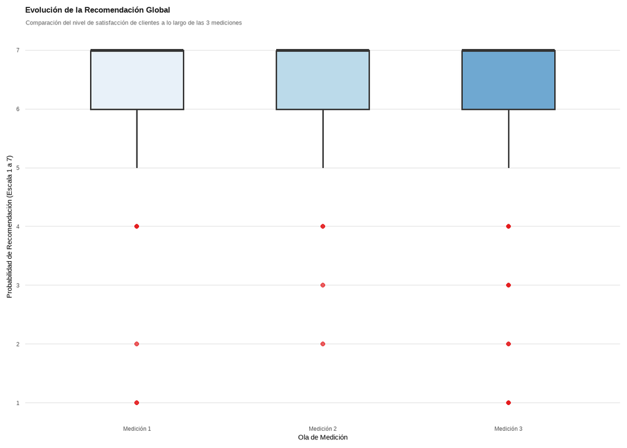

```r
# 1. Asegurar la limpieza y forzar que 'medicion' sea un factor con orden cronológico (Sólo para efecto de este gráfico)
encuesta_df_plot <- encuesta_df %>%
  filter(!is.na(recomendacion)) %>%
  mutate(medicion = factor(medicion,
                           levels = c("Medición 1", "Medición 2", "Medición 3"),
                           ordered = TRUE))

# 2. Graficar los 3 boxplots en el mismo lienzo
ggplot(encuesta_df_plot, aes(x = medicion, y = recomendacion, fill = medicion)) +
  # Dibujar los gráficos de caja limpios con un ancho adecuado
  geom_boxplot(width = 0.5,
               outlier.color = "#E41A1C", # Rojo sobrio para destacar atípicos reales
               outlier.size = 1.5,
               alpha = 0.7,
               lwd = 0.6) +

  # Colores gama de azules
  scale_fill_brewer(palette = "Blues") +

  # Forzar el eje Y a mostrar estrictamente la escala Likert 1-7
  scale_y_continuous(breaks = 1:7, limits = c(1, 7)) +

  # Etiquetas
  labs(
    title = "Evolución de la Recomendación Global",
    subtitle = "Comparación del nivel de satisfacción de clientes a lo largo de las 3 mediciones",
    x = "Ola de Medición",
    y = "Probabilidad de Recomendación (Escala 1 a 7)"
  ) +

  # Tema visual limpio y sin distracciones
  theme_minimal(base_size = 11) +
  theme(
    plot.title = element_text(face = "bold", size = 13, color = "gray10"),
    plot.subtitle = element_text(size = 9.5, color = "gray40"),
    legend.position = "none", # Ocultamos la leyenda porque el eje X ya identifica las olas
    panel.grid.minor = element_blank(),
    panel.grid.major.x = element_blank() # Quitamos las líneas verticales para que se vea más pulcro
  )
```

## 3.2 Análisis descriptivo y cruces por segmento

🔎 Los dos segmentos principales para realizar este cruce son `rol_proyecto` y `sector_empresa`.

### Distribución de la percepción de servicio según rol del cliente

Calculamos el promedio de las variables de recomendación y esfuerzo (`facilidad_resolucion`), cuenta cuántos clientes pertenecen a cada rol y los ordena de mayor a menor satisfacción.

```r
# 1. Tabla Resumen: Satisfacción y esfuerzo por Rol
resumen_rol <- encuesta_df %>%
  filter(!is.na(rol_proyecto), !is.na(recomendacion)) %>%
  group_by(rol_proyecto) %>%
  summarise(
    n_clientes = n(),
    promedio_recomendacion = round(mean(recomendacion), 2),
    promedio_facilidad = round(mean(facilidad_resolucion, na.rm = TRUE), 2),
    .groups = "drop"
  ) %>%
  arrange(desc(promedio_recomendacion))

print(resumen_rol)
```

```
## # A tibble: 20 × 4
##    rol_proyecto             n_clientes promedio_recomendacion promedio_facilidad
##    <chr>                         <int>                  <dbl>              <dbl>
##  1 Calidad                           1                   7                  6
##  2 Prevención de Riesgos /…          3                   7                  6.67
##  3 Superintendencia                  2                   7                  7
##  4 Capataz / Maestro de Ob…          8                   6.88               6.88
##  5 Administración / Finanz…         15                   6.8                6.54
##  6 Otros                            27                   6.74               6.64
##  7 Jefe de otras áreas no …          7                   6.71               5.8
##  8 Ingeniería / Estudios            11                   6.64               6.12
##  9 Supervisor de Andamios           21                   6.57               6.13
## 10 Jefe de Terreno                  43                   6.51               6.3
## 11 Comercial                         2                   6.5                5.5
## 12 Gerente de Proyecto              52                   6.5                6.24
## 13 Operaciones / Logística           8                   6.5                5.38
## 14 Prevencionista de Riesg…         29                   6.48               6.26
## 15 Jefe de Bodega                   47                   6.3                6.18
## 16 Administrador de Obra            74                   6.18               6.02
## 17 Compras / Abastecimiento         12                   6.08               6.14
## 18 Jefe de Obra                      5                   6                  5.6
## 19 Oficina Técnica                  35                   5.89               5.48
## 20 Dirección General                 7                   5.43               5.67
```

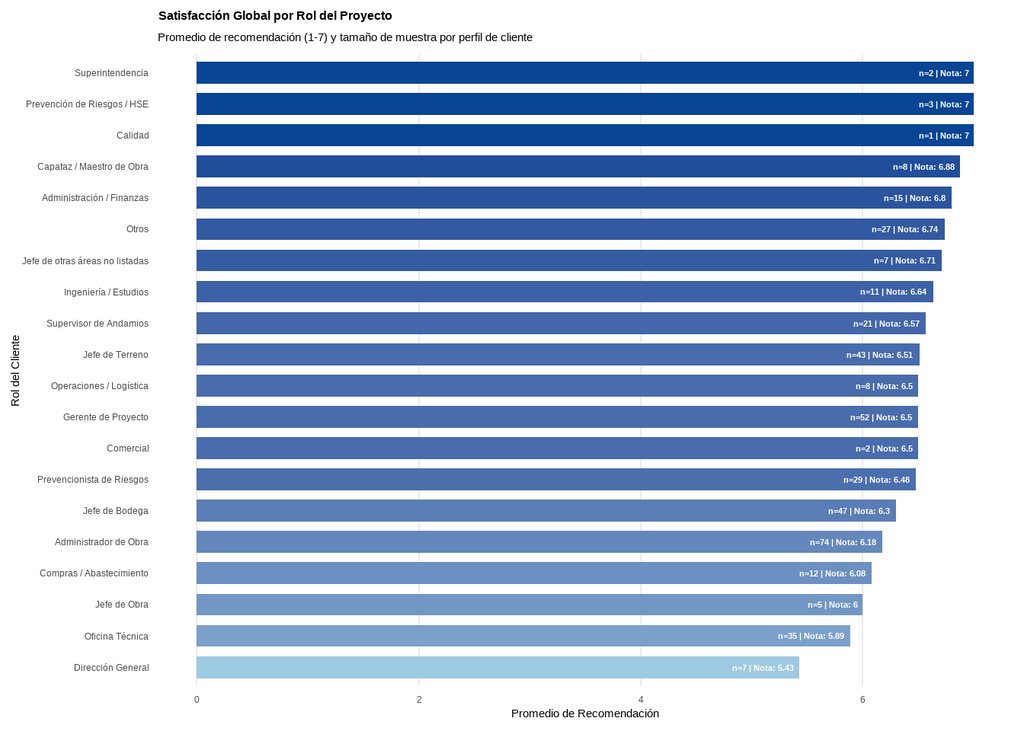

```r
# 2. Gráfico de Barras Horizontales Ordenadas por Recomendación
ggplot(resumen_rol, aes(x = reorder(rol_proyecto, promedio_recomendacion), y = promedio_recomendacion, fill = promedio_recomendacion)) +
  geom_col(width = 0.7) +
  geom_text(aes(label = paste0("n=", n_clientes, " | Nota: ", promedio_recomendacion)),
            hjust = 1.1, color = "white", fontface = "bold", size = 3) +
  coord_flip() + # Voltear el gráfico para leer fácilmente los roles
  scale_fill_gradient(low = "#9ECAE1", high = "#084594") + # Degradado azul profesional
  labs(
    title = "Satisfacción Global por Rol del Proyecto",
    subtitle = "Promedio de recomendación (1-7) y tamaño de muestra por perfil de cliente",
    x = "Rol del Cliente",
    y = "Promedio de Recomendación"
  ) +
  theme_minimal(base_size = 11) +
  theme(
    plot.title = element_text(face = "bold", size = 12),
    legend.position = "none",
    panel.grid.minor = element_blank(),
    panel.grid.major.y = element_blank()
  )
```

### Análisis de satisfacción según sector productivo de la empresa

```r
# 1. Tabla Resumen por Sector de la Empresa (limpiando espacios invisibles con trimws)
resumen_sector <- encuesta_df_sector_largo %>%
  mutate(sector_empresa = trimws(sector_empresa)) %>%
  filter(!is.na(sector_empresa), !is.na(recomendacion)) %>%
  group_by(sector_empresa) %>%
  summarise(
    n_respuestas = n(),
    promedio_recomendacion = round(mean(recomendacion), 2),
    promedio_facilidad = round(mean(facilidad_resolucion, na.rm = TRUE), 2),
    .groups = "drop"
  ) %>%
  arrange(desc(promedio_recomendacion))

print(resumen_sector)
```

```
## # A tibble: 21 × 4
##    sector_empresa         n_respuestas promedio_recomendacion promedio_facilidad
##    <chr>                         <int>                  <dbl>              <dbl>
##  1 Otros (especifique) -…            1                   7                NaN
##  2 Otros (especifique) -…            1                   7                  7
##  3 Otros (especifique) -…            1                   7                  7
##  4 Planta forestal                   4                   7                  5.75
##  5 Restauración                     12                   7                  6.11
##  6 Municipalidades y ser…            9                   6.89               5.88
##  7 Contratista / instala…           15                   6.87               6.17
##  8 Eventos y espectáculos           20                   6.8                6.33
##  9 Planta GNL                       10                   6.8                5.62
## 10 Planta refinería                 15                   6.67               6.15
## # ℹ 11 more rows
```

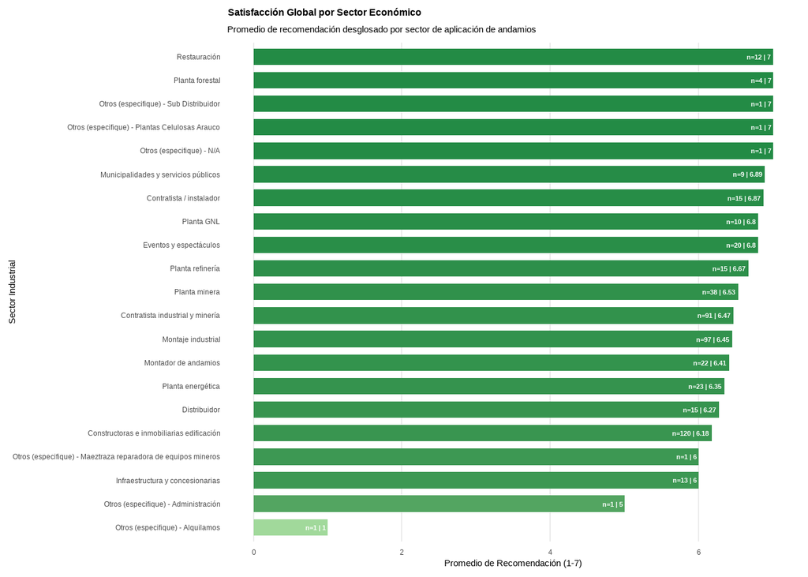

```r
# 2. Gráfico por Sector
ggplot(resumen_sector, aes(x = reorder(sector_empresa, promedio_recomendacion), y = promedio_recomendacion, fill = promedio_recomendacion)) +
  geom_col(width = 0.7) +
  geom_text(aes(label = paste0("n=", n_respuestas, " | ", promedio_recomendacion)),
            hjust = 1.1, color = "white", fontface = "bold", size = 3) +
  coord_flip() +
  scale_fill_gradient(low = "#A1D99B", high = "#238B45") + # Degradado verde (distinto al de roles para evitar confusión)
  labs(
    title = "Satisfacción Global por Sector Económico",
    subtitle = "Promedio de recomendación desglosado por sector de aplicación de andamios",
    x = "Sector Industrial",
    y = "Promedio de Recomendación (1-7)"
  ) +
  theme_minimal(base_size = 11) +
  theme(
    plot.title = element_text(face = "bold", size = 12),
    legend.position = "none",
    panel.grid.minor = element_blank(),
    panel.grid.major.y = element_blank()
  )
```

#### Tabla de contingencia y estadísticos por rubro económico

```r
encuesta_df_sector_largo <- encuesta_df_sector_largo %>%
  mutate(rubro_macro = case_when(
    sector_empresa %in% c("Constructoras e inmobiliarias edificación",
                           "Montador de andamios",
                           "Contratista / instalador",
                           "Infraestructura y concesionarias",
                           "Restauración",
                           "Otros (especifique) - Construccion") ~ "Construcción",
    sector_empresa %in% c("Montaje industrial",
                           "Contratista industrial y minería",
                           "Planta energética",
                           "Planta refinería",
                           "Planta GNL",
                           "Planta forestal",
                           "Otros (especifique) - Plantas Celulosas Arauco") ~ "Industrial",
    sector_empresa %in% c("Planta minera",
                           "Otros (especifique) - Maeztraza reparadora de equipos mineros") ~ "Minero",
    TRUE ~ "Otro"
  ))

# Verificación
  encuesta_df_sector_largo %>%
  count(rubro_macro, sector_empresa) %>%
  arrange(rubro_macro, str_starts(sector_empresa, "Otros \\(especifique\\)"), desc(n))
```

```
## # A tibble: 22 × 3
##    rubro_macro  sector_empresa                                n
##    <chr>        <chr>                                     <int>
##  1 Construcción Constructoras e inmobiliarias edificación   123
##  2 Construcción Montador de andamios                         24
##  3 Construcción Contratista / instalador                     15
##  4 Construcción Infraestructura y concesionarias             14
##  5 Construcción Restauración                                 12
##  6 Construcción Otros (especifique) - Construccion            1
##  7 Industrial   Montaje industrial                          100
##  8 Industrial   Contratista industrial y minería             94
##  9 Industrial   Planta energética                            23
## 10 Industrial   Planta refinería                             15
## # ℹ 12 more rows
```

#### Visualización comparativa de satisfacción por sector

```r
resumen_rubro <- encuesta_df_sector_largo %>%
  filter(!is.na(recomendacion)) %>%
  group_by(rubro_macro) %>%
  summarise(
    n_clientes = n(),
    promedio_recomendacion = round(mean(recomendacion, na.rm = TRUE), 2),
    .groups = "drop"
  ) %>%
  arrange(desc(promedio_recomendacion))

print(resumen_rubro)
```

```
## # A tibble: 4 × 3
##   rubro_macro  n_clientes promedio_recomendacion
##   <chr>             <int>                  <dbl>
## 1 Minero               39                   6.51
## 2 Otro                 48                   6.5
## 3 Industrial          241                   6.49
## 4 Construcción        182                   6.31
```

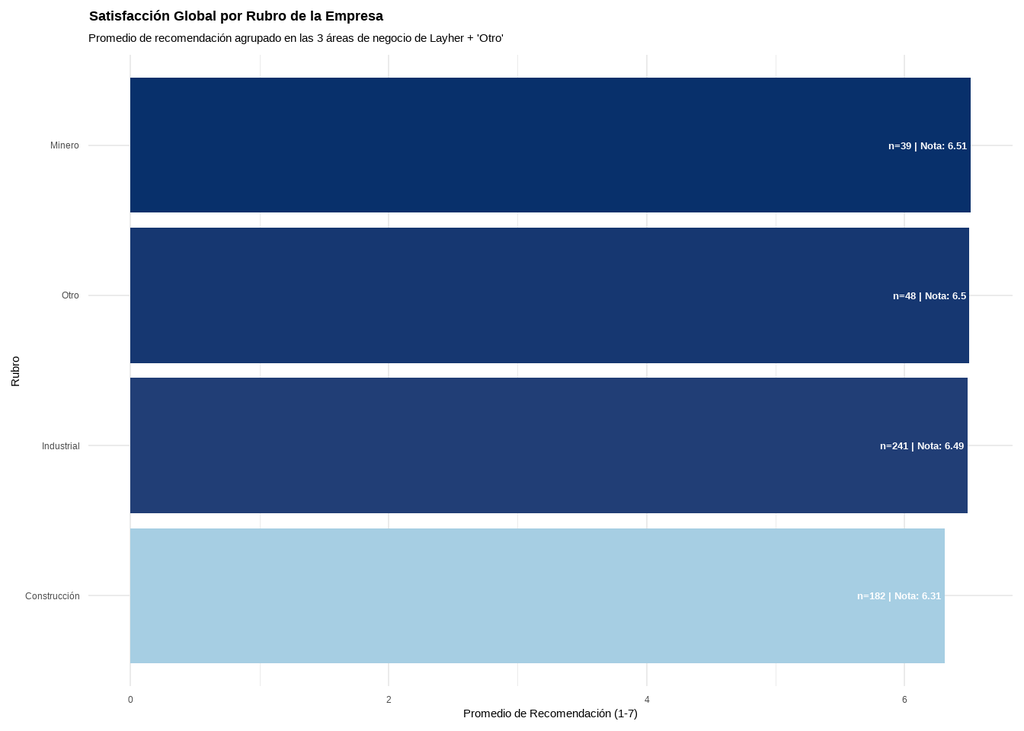

```r
ggplot(resumen_rubro, aes(x = reorder(rubro_macro, promedio_recomendacion),
                          y = promedio_recomendacion,
                          fill = promedio_recomendacion)) +
  geom_col() +
  geom_text(aes(label = paste0("n=", n_clientes, " | Nota: ", promedio_recomendacion)),
            hjust = 1.05, color = "white", size = 3.5, fontface = "bold") +
  coord_flip() +
  scale_fill_gradient(low = "#a6cee3", high = "#08306b") +
  labs(
    title = "Satisfacción Global por Rubro de la Empresa",
    subtitle = "Promedio de recomendación agrupado en las 3 áreas de negocio de Layher + 'Otro'",
    x = "Rubro",
    y = "Promedio de Recomendación (1-7)"
  ) +
  theme_minimal(base_size = 11) +
  theme(legend.position = "none",
        plot.title = element_text(face = "bold"))
```

# 4. Análisis de Asociación y Correlaciones

## 4.1 Matrices de correlación lineal

### Matriz de correlación para el núcleo de evaluación general (17 ítems)

Creamos un diccionario de traducción (nombre largo -> Alias corto). Sólo para efectos de la matriz.

```r
#Excluir las variables digitales 16-17 ("satisfaccion_capscaff" y "satisfaccion_webscaff")
vars_generales <- setdiff(
  variables_numericas_comparables,
  c("satisfaccion_capscaff", "satisfaccion_webscaff")
)
#Generar el diccionario de correspondencia (Tabla para tener a la vista)
diccionario_alias <- tibble(
  alias           = paste0("V", seq_along(vars_generales)),
  nombre_variable = vars_generales
)
# Imprimir la tabla de equivalencias
print(diccionario_alias, n = Inf)
```

```
## # A tibble: 17 × 2
##    alias nombre_variable
##    <chr> <chr>
##  1 V1    recomendacion
##  2 V2    facilidad_resolucion
##  3 V3    precio_calidad
##  4 V4    amabilidad_del_equipo_tecnico
##  5 V5    amabilidad_en_la_atencion_comercial
##  6 V6    calidad_del_despacho_de_los_equipos_ausencia_de_errores_de_envio_estad…
##  7 V7    calidad_del_servicio_de_diseno_de_proyectos
##  8 V8    calidad_del_servicio_de_induccion_tecnica
##  9 V9    calidad_del_servicio_de_ingenieria
## 10 V10   calidad_del_servicio_de_visita_tecnica
## 11 V11   claridad_de_la_informacion_en_cotizaciones
## 12 V12   claridad_del_informe_de_la_visita_tecnica
## 13 V13   efectividad_en_la_atencion_comercial
## 14 V14   facilidad_para_coordinar_y_realizar_devolucion_de_equipos_en_arriendo
## 15 V15   productos_de_scaff_co_en_general
## 16 V16   servicios_de_scaff_co_en_general
## 17 V17   tiempo_de_respuesta_en_las_cotizaciones_solicitadas
```

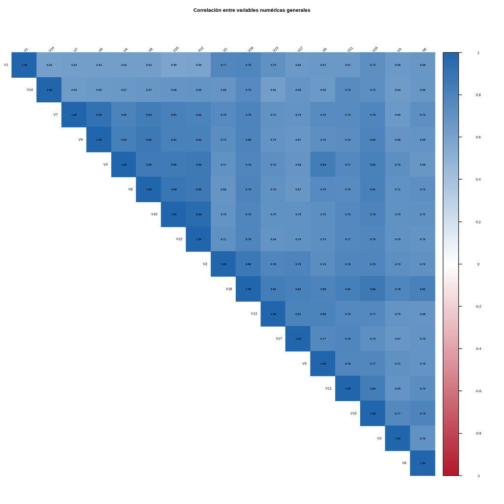

```r
# Crear subconjunto temporal y renombrar únicamente las columnas de este objeto
df_corr_temp <- encuesta_df %>%
  select(all_of(vars_generales))

colnames(df_corr_temp) <- diccionario_alias$alias

# Calcular la matriz de correlación (Pearson) omitiendo NAs por pares
matriz_cor <- cor(df_corr_temp, use = "pairwise.complete.obs")

# Configuración del gráfico con tus parámetros visuales
par(mar = c(0, 0, 2, 0))

corrplot(
  matriz_cor,
  method      = "color",
  type        = "upper",
  order       = "hclust",
  tl.col      = "black",
  tl.cex      = 0.8,
  tl.srt      = 45,
  addCoef.col = "black",
  number.cex  = 0.65,
  col         = colorRampPalette(c("#B2182B", "white", "#2166AC"))(200),
  title       = "Correlación entre variables numéricas generales",
  mar         = c(0, 0, 2, 0)
)
```

### Correlación en módulos específicos de servicios digitales

```r
cor_webscaff_capscaff <- encuesta_df %>%
  filter(!is.na(satisfaccion_webscaff) | !is.na(satisfaccion_capscaff)) %>%
  select(recomendacion, precio_calidad, satisfaccion_webscaff, satisfaccion_capscaff) %>%
  cor(use = "pairwise.complete.obs")

print(cor_webscaff_capscaff)
```

```
##                       recomendacion precio_calidad satisfaccion_webscaff
## recomendacion             1.0000000      0.5181771             0.4023950
## precio_calidad            0.5181771      1.0000000             0.4860072
## satisfaccion_webscaff     0.4023950      0.4860072             1.0000000
## satisfaccion_capscaff     0.3280815      0.3612967             0.5710475
##                       satisfaccion_capscaff
## recomendacion                     0.3280815
## precio_calidad                    0.3612967
## satisfaccion_webscaff             0.5710475
## satisfaccion_capscaff             1.0000000
```

```r
# Cuántos casos válidos hay detrás de cada correlación (importante mostrarlo, dado el missing alto)
n_pares <- encuesta_df %>%
  filter(!is.na(satisfaccion_webscaff) | !is.na(satisfaccion_capscaff)) %>%
  select(recomendacion, precio_calidad, satisfaccion_webscaff, satisfaccion_capscaff) %>%
  {crossprod(!is.na(.))}

print(n_pares)
```

```
##                       recomendacion precio_calidad satisfaccion_webscaff
## recomendacion                   179            168                   157
## precio_calidad                  168            168                   149
## satisfaccion_webscaff           157            149                   157
## satisfaccion_capscaff            63             56                    41
##                       satisfaccion_capscaff
## recomendacion                            63
## precio_calidad                           56
## satisfaccion_webscaff                    41
## satisfaccion_capscaff                    63
```

### Distribución e histogramas de las 19 variables cuantitativas

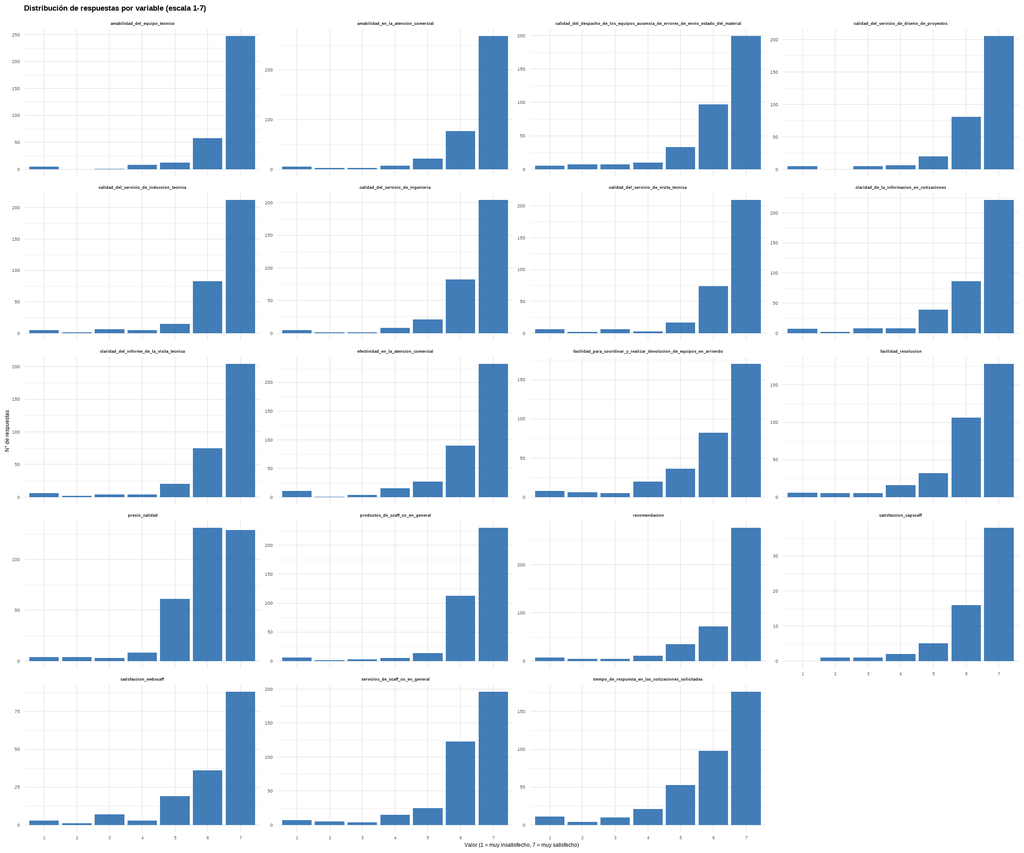

```r
datos_largo <- encuesta_df %>%
  select(all_of(variables_numericas_comparables)) %>%
  pivot_longer(everything(), names_to = "variable", values_to = "valor") %>%
  filter(!is.na(valor))

ggplot(datos_largo, aes(x = factor(valor))) +
  geom_bar(fill = "#2166AC", alpha = 0.85) +
  facet_wrap(~ variable, scales = "free_y", ncol = 4) +
  labs(
    title = "Distribución de respuestas por variable (escala 1-7)",
    x = "Valor (1 = muy insatisfecho, 7 = muy satisfecho)",
    y = "N° de respuestas"
  ) +
  theme_minimal(base_size = 9) +
  theme(
    strip.text = element_text(size = 7, face = "bold"),
    axis.text.x = element_text(size = 7),
    plot.title = element_text(face = "bold", size = 13)
  )
```

# 5. Reducción de Dimensionalidad y Segmentación de Clientes

## 5.1 Análisis de Componentes Principales (PCA)

💡 La matriz de correlación mostró que las 17 variables numéricas generales están muy correlacionadas entre sí (efecto halo). Antes de cualquier modelo, usamos PCA para entender cuánta información es realmente independiente, y evitar que las variables casi redundantes (visita técnica / claridad del informe; diseño / ingeniería) pesen doble en análisis posteriores.

```r
datos_pca <- encuesta_df %>%
  select(all_of(vars_generales)) %>%
  filter(complete.cases(.))

cat("Filas usadas (con las 17 variables completas):", nrow(datos_pca), "de", nrow(encuesta_df), "\n")
```

```
## Filas usadas (con las 17 variables completas): 260 de 427
```

```r
pca_result <- prcomp(datos_pca, scale. = TRUE)
summary(pca_result)
```

```
## Importance of components:
##                          PC1     PC2     PC3     PC4     PC5    PC6     PC7
## Standard deviation     3.611 0.93592 0.67441 0.63728 0.59670 0.5547 0.53058
## Proportion of Variance 0.767 0.05153 0.02675 0.02389 0.02094 0.0181 0.01656
## Cumulative Proportion  0.767 0.81856 0.84532 0.86921 0.89015 0.9083 0.92481
##                            PC8     PC9   PC10    PC11    PC12    PC13    PC14
## Standard deviation     0.46600 0.44766 0.4384 0.42166 0.36912 0.32763 0.30893
## Proportion of Variance 0.01277 0.01179 0.0113 0.01046 0.00801 0.00631 0.00561
## Cumulative Proportion  0.93759 0.94937 0.9607 0.97114 0.97915 0.98547 0.99108
##                           PC15    PC16    PC17
## Standard deviation     0.26739 0.21170 0.18792
## Proportion of Variance 0.00421 0.00264 0.00208
## Cumulative Proportion  0.99529 0.99792 1.00000
```

Varianza explicada por componente

```r
library(factoextra)
```

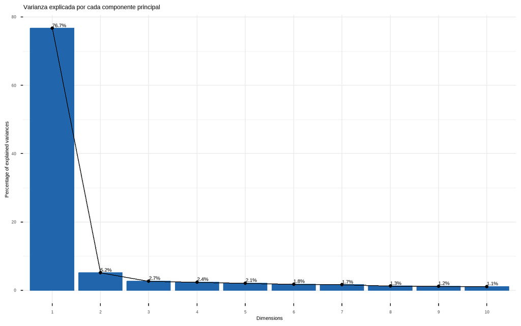

```r
fviz_eig(pca_result, addlabels = TRUE, barfill = "#2166AC", barcolor = "#2166AC") +
  labs(title = "Varianza explicada por cada componente principal")
```

### Cargas factoriales (loadings) y contribución de variables a PC1 y PC2

```r
#DICCIONARIO DE ALIAS Y TABLA DE CORRESPONDENCIAS (Para la leyenda)

# Extraer los nombres de las variables evaluadas en el PCA
nombres_pca <- rownames(pca_result$rotation)

# Crear el diccionario con identificadores cortos (V1, V2, ...)
diccionario_pca <- tibble(
  alias           = paste0("V", seq_along(nombres_pca)),
  variable_origen = nombres_pca
)

# Imprimir la tabla de equivalencias para tenerla como referencia en el informe
print(diccionario_pca, n = Inf)
```

```
## # A tibble: 17 × 2
##    alias variable_origen
##    <chr> <chr>
##  1 V1    recomendacion
##  2 V2    facilidad_resolucion
##  3 V3    precio_calidad
##  4 V4    amabilidad_del_equipo_tecnico
##  5 V5    amabilidad_en_la_atencion_comercial
##  6 V6    calidad_del_despacho_de_los_equipos_ausencia_de_errores_de_envio_estad…
##  7 V7    calidad_del_servicio_de_diseno_de_proyectos
##  8 V8    calidad_del_servicio_de_induccion_tecnica
##  9 V9    calidad_del_servicio_de_ingenieria
## 10 V10   calidad_del_servicio_de_visita_tecnica
## 11 V11   claridad_de_la_informacion_en_cotizaciones
## 12 V12   claridad_del_informe_de_la_visita_tecnica
## 13 V13   efectividad_en_la_atencion_comercial
## 14 V14   facilidad_para_coordinar_y_realizar_devolucion_de_equipos_en_arriendo
## 15 V15   productos_de_scaff_co_en_general
## 16 V16   servicios_de_scaff_co_en_general
## 17 V17   tiempo_de_respuesta_en_las_cotizaciones_solicitadas
```

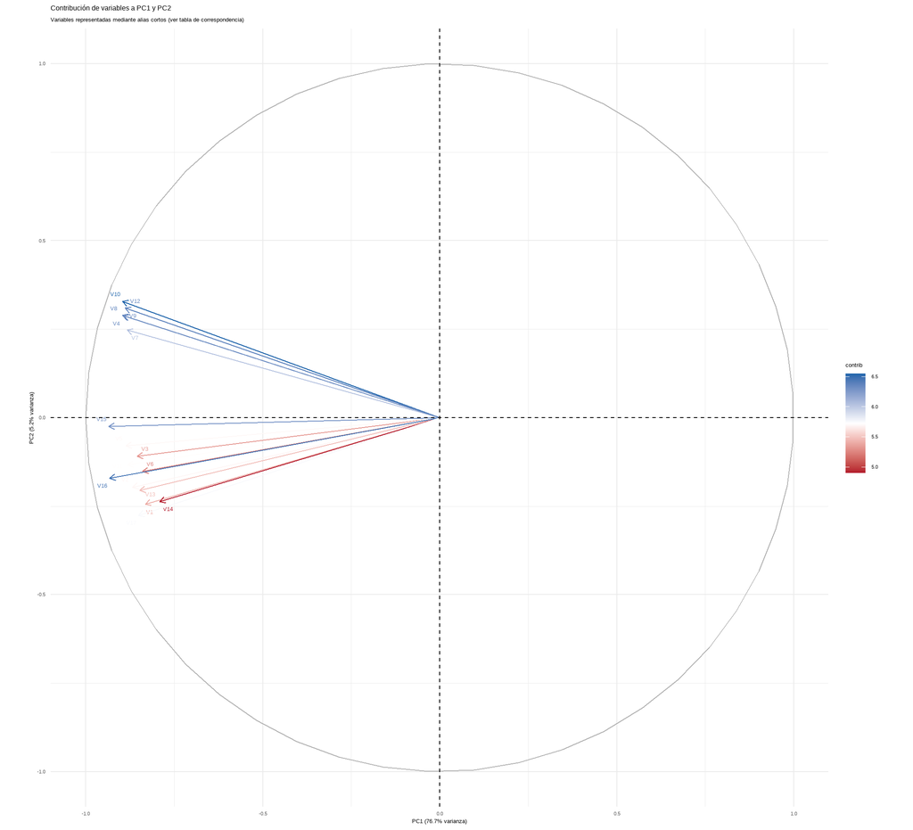

```r
#COPIA TEMPORAL DEL OBJETO PCA Y ASIGNACIÓN DE ALIAS
# Clonamos el resultado del PCA en un objeto temporal aislado
pca_temp <- pca_result

# Reasignamos los nombres únicamente en los componentes internos de la copia
rownames(pca_temp$rotation) <- diccionario_pca$alias
names(pca_temp$center)      <- diccionario_pca$alias
names(pca_temp$scale)       <- diccionario_pca$alias

#GRÁFICO DE CONTRIBUCIÓN DE VARIABLES CON NOMBRES CORTOS
fviz_pca_var(
  pca_temp,
  col.var       = "contrib",
  gradient.cols = c("#B2182B", "white", "#2166AC"),
  repel         = TRUE,
  labelsize     = 3.5,
  arrowsize     = 0.5
) +
  labs(
    title    = "Contribución de variables a PC1 y PC2",
    subtitle = "Variables representadas mediante alias cortos (ver tabla de correspondencia)",
    x        = paste0("PC1 (", round(summary(pca_result)$importance[2, 1] * 100, 1), "% varianza)"),
    y        = paste0("PC2 (", round(summary(pca_result)$importance[2, 2] * 100, 1), "% varianza)")
  ) +
  theme_minimal(base_size = 10)
```

## 5.2 Segmentación no supervisada mediante algoritmo K-Means

### Ajuste del modelo K-Means proyectado sobre el espacio latente del PCA

💡 Usamos los primeros 2 componentes del PCA (82% de la varianza) para poder visualizar los clusters en un plano.

```r
scores <- as.data.frame(pca_result$x[, 1:2])
```

### Determinación del número óptimo de grupos

¿Cuántos clusters tiene sentido usar?

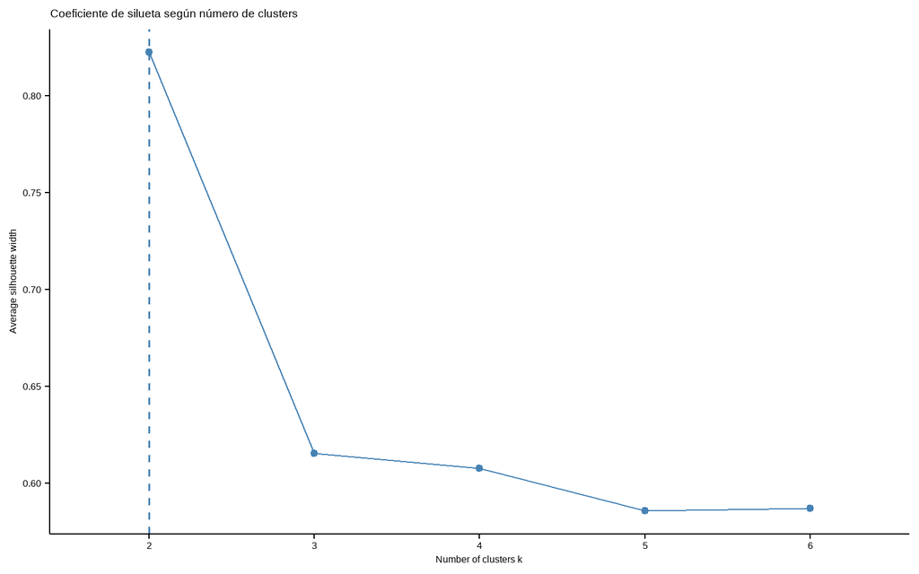

```r
fviz_nbclust(scores, kmeans, method = "silhouette", k.max = 6) +
  labs(title = "Coeficiente de silueta según número de clusters")
```

### Ajuste y convergencia del modelo

Modelo final (k=2)

```r
set.seed(123)
km_final <- kmeans(scores, centers = 2, nstart = 25)

datos_pca$cluster <- factor(km_final$cluster)

table(datos_pca$cluster)
```

```
##
##   1   2
##   9 251
```

### Representación gráfica de los clusters

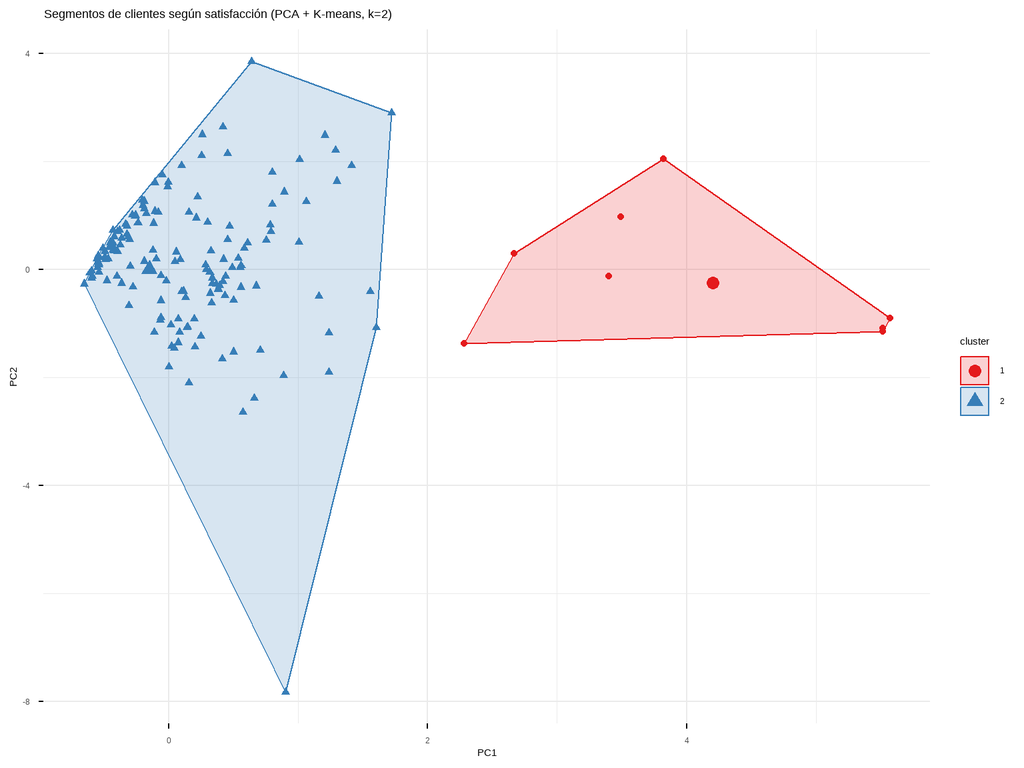

```r
fviz_cluster(km_final, data = scores,
             palette = c("#E41A1C", "#377EB8"),
             geom = "point",
             ellipse.type = "convex",
             ggtheme = theme_minimal(),
             main = "Segmentos de clientes según satisfacción (PCA + K-means, k=2)")
```

### Caracterización y perfil estadístico de los segmentos

```r
perfil_clusters <- datos_pca %>%
  group_by(cluster) %>%
  summarise(across(all_of(vars_generales), ~ round(mean(.x), 2)), n = n(), .groups = "drop")

print(as.data.frame(perfil_clusters))
```

```
##   cluster recomendacion facilidad_resolucion precio_calidad
## 1       1          2.56                 2.11           1.89
## 2       2          6.59                 6.36           6.20
##   amabilidad_del_equipo_tecnico amabilidad_en_la_atencion_comercial
## 1                          2.78                                3.11
## 2                          6.72                                6.69
##   calidad_del_despacho_de_los_equipos_ausencia_de_errores_de_envio_estado_del_material
## 1                                                                                 2.11
## 2                                                                                 6.38
##   calidad_del_servicio_de_diseno_de_proyectos
## 1                                        2.67
## 2                                        6.56
##   calidad_del_servicio_de_induccion_tecnica calidad_del_servicio_de_ingenieria
## 1                                      2.22                               2.56
## 2                                      6.58                               6.59
##   calidad_del_servicio_de_visita_tecnica
## 1                                   2.11
## 2                                   6.58
##   claridad_de_la_informacion_en_cotizaciones
## 1                                       2.33
## 2                                       6.50
##   claridad_del_informe_de_la_visita_tecnica
## 1                                      2.33
## 2                                      6.57
##   efectividad_en_la_atencion_comercial
## 1                                 2.22
## 2                                 6.58
##   facilidad_para_coordinar_y_realizar_devolucion_de_equipos_en_arriendo
## 1                                                                  1.67
## 2                                                                  6.22
##   productos_de_scaff_co_en_general servicios_de_scaff_co_en_general
## 1                             2.33                             1.89
## 2                             6.63                             6.47
##   tiempo_de_respuesta_en_las_cotizaciones_solicitadas   n
## 1                                                2.00   9
## 2                                                6.29 251
```

### Asociación cruzada entre segmentos identificados y roles de cliente

Cruce con rol del proyecto

```r
idx_keep <- which(complete.cases(encuesta_df %>% select(all_of(vars_generales))))
encuesta_df_clustered <- encuesta_df[idx_keep, ]
encuesta_df_clustered$cluster <- factor(km_final$cluster)

encuesta_df_clustered %>%
  count(cluster, rol_proyecto) %>%
  arrange(cluster, rol_proyecto == "Otros", desc(n))
```

```
## # A tibble: 26 × 3
##    cluster rol_proyecto                        n
##    <fct>   <chr>                           <int>
##  1 1       Administrador de Obra               3
##  2 1       Dirección General                   1
##  3 1       Gerente de Proyecto                 1
##  4 1       Jefe de Obra                        1
##  5 1       Jefe de otras áreas no listadas     1
##  6 1       Oficina Técnica                     1
##  7 1       Prevencionista de Riesgos           1
##  8 2       Administrador de Obra              53
##  9 2       Gerente de Proyecto                32
## 10 2       Jefe de Bodega                     32
## # ℹ 16 more rows
```

# 6. Minería de Texto en Respuestas Abiertas

## 6.1 Procesamiento del lenguaje natural y extracción de temas cualitativos

💡 Como complemento al análisis cuantitativo, se revisaron los comentarios abiertos (`comentario_sugerencia`, `razon_recomendacion`) para identificar patrones temáticos no capturados por las variables de escala. La lectura inicial y propuesta de categorías se apoyó en IA generativa (Claude); la cuantificación se implementó y verificó en R.

```r
texto_combinado <- encuesta_df %>%
  select(comentario_sugerencia, razon_recomendacion) %>%
  pivot_longer(everything(), values_to = "texto") %>%
  filter(!is.na(texto)) %>%
  mutate(texto = tolower(texto))

cat("Total de respuestas de texto libre analizadas:", nrow(texto_combinado), "\n")
```

```
## Total de respuestas de texto libre analizadas: 531
```

```r
# Frecuencia de temas recurrentes, detectados por palabras clave
temas <- tibble::tribble(
  ~tema, ~patron,
  "Stock / repuestos / accesorios disponibles", "stock|repuesto|accesorio",
  "Tiempos de espera / demora (general)", "demor|lent|espera|tard",
  "Devolución (proceso)", "devoluci[oó]n|devolver",
  "Daños / material dañado en devolución", "da[ñn]|deterior",
  "Certificación / calidad del sistema", "certificad"
)

resumen_temas <- temas %>%
  rowwise() %>%
  mutate(n_menciones = sum(str_detect(texto_combinado$texto, regex(patron)), na.rm = TRUE)) %>%
  ungroup() %>%
  arrange(desc(n_menciones))

print(resumen_temas)
```

```
## # A tibble: 5 × 3
##   tema                                       patron                  n_menciones
##   <chr>                                      <chr>                         <int>
## 1 Tiempos de espera / demora (general)       demor|lent|espera|tard           49
## 2 Stock / repuestos / accesorios disponibles stock|repuesto|accesor…          17
## 3 Devolución (proceso)                       devoluci[oó]n|devolver           16
## 4 Daños / material dañado en devolución      da[ñn]|deterior                  15
## 5 Certificación / calidad del sistema        certificad                        9
```

## 6.2 Visualización de términos frecuentes y asociación de marca

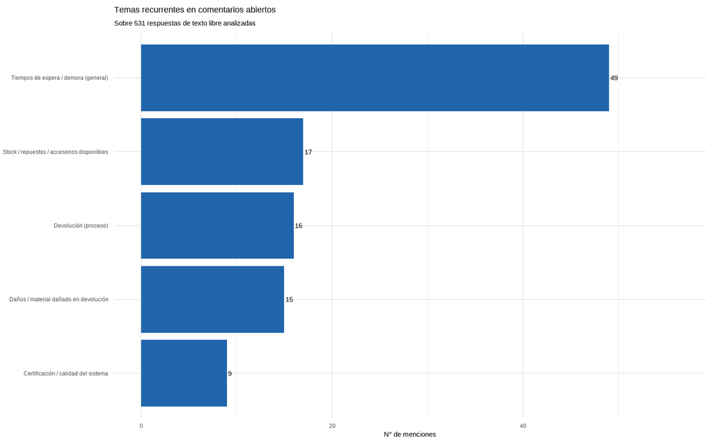

```r
ggplot(resumen_temas, aes(x = reorder(tema, n_menciones), y = n_menciones)) +
  geom_col(fill = "#2166AC") +
  geom_text(aes(label = n_menciones), hjust = -0.2) +
  coord_flip() +
  labs(title = "Temas recurrentes en comentarios abiertos",
       subtitle = paste0("Sobre ", nrow(texto_combinado), " respuestas de texto libre analizadas"),
       x = NULL, y = "N° de menciones") +
  theme_minimal(base_size = 11) +
  expand_limits(y = max(resumen_temas$n_menciones) * 1.15)
```